# Replication of BKR

Shunsuke Matsuno

2020/6/1

# Required libraries

```r
easypackages::libraries('tidyverse', 'ggplot2', 'NumbersGame')
```

# Introduction

- This note replicates Bird, Karolyi, and Ruchti (BKR; 2019, JAE).

# Simulating the data

- Since I don’t have access to the original data, I simulate the “observed” data using the estimated parameters in BKR.

## Parameters

- $\theta = (\eta, \gamma, \psi^2, \zeta)$

```r
set.seed(2020)

# Table 4
eta <- 0.5  # marginal cost
gamma <- 2.0817    # curvature
psi2 <- 0.8201   # variance
zeta <- 3.7105    # variance multiplier
theta <- c(eta, gamma, psi2, zeta)
```

## Benefit function

- Since the estimates of full model (coefficients on polynomials) are not reported, I approximate the capital market benefit function by `compute_benefit.R`.

## Latent earnings distribution

- I assume that latent earnings distribution is generated by normal distribution.
- I set the number of firms (observations) to $100,000$.
  - In BKR, the number of observations is $49,604$.
- I use the following multinomial distribution as a discretized normal:

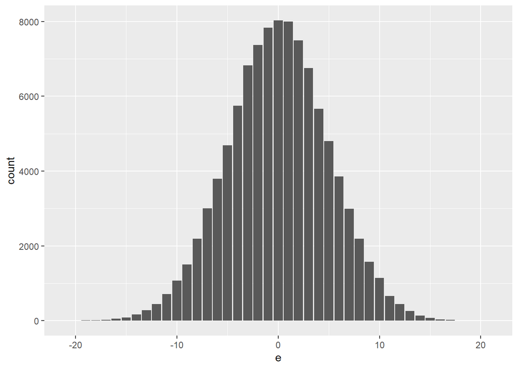

```r
# number of firms
N <- 100000
sigma <- 5

df_firm <- simulate_firm(S = N, sigma)

ggplot(df_firm, aes(x = e)) +
  geom_bar() +
  xlim(-21, 21)
```

## Manipulation

- Each firm decides the amount of manipulation, $m$, according to the maximization problem.
- `compute_utility` computes the following utility:
  $$u_{\text {Discrete}}(b, m, \theta)=\sum_{-20}^{20} \phi_{m, \theta}(\varepsilon) \mathcal{B}(b+m+\varepsilon) d \varepsilon-\beta_{b} m^{\gamma}$$
- Since I don’t have the original data, I am assuming the following benefit function.
  - There is a jump by $1.5$ at $R=0$.

$$\mathcal{B}(R)=\begin{cases}
0.05R-1 & R<0\\
0.05R+0.5 & R\ge0
\end{cases}$$

```r
df_firm_utility <- compute_optimal_manipulation_simulated(df_firm, theta, S = N)
df_firm_utility
```

| firm | e | beta | m_opt | eps_after | R |
| --- | --- | --- | --- | --- | --- |
| 1 | -4 | 7.618748e-03 | 6 | -5 | -3 |
| 2 | -5 | 9.765654e-01 | 0 | 0 | -5 |
| 3 | -1 | 2.977551e-01 | 1 | 0 | 0 |
| 4 | -7 | 5.099718e-01 | 0 | 0 | -7 |
| 5 | 4 | 9.952584e-01 | 0 | 0 | 4 |
| 6 | 1 | 7.046751e-01 | 0 | 0 | 1 |
| 7 | -8 | 1.724356e-01 | 0 | 0 | -8 |
| 8 | -5 | 3.771809e-01 | 0 | 0 | -5 |
| 9 | 1 | 5.419038e-01 | 0 | 0 | 1 |
| 10 | 1 | 4.475464e-01 | 0 | 0 | 1 |

[output cut: 9990 more lines]

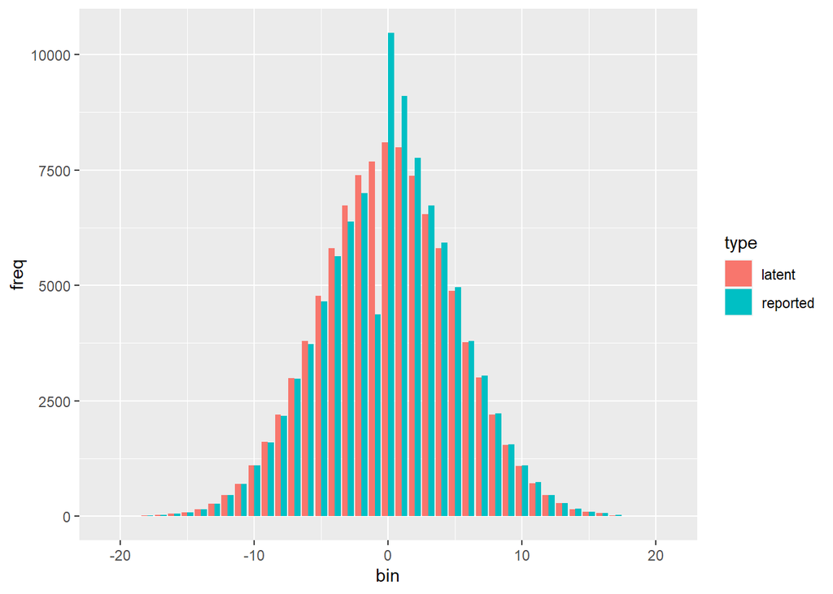

```r
# plot
plot_latent_reported(df_firm_utility)
```

- The ‘empirical’ distribution of earnings surprises, $R$, is a bit drastic than the actual empirical distribution.
  - Compare the following graph with Fig.2.
  - This is because my simulation assumes that the empirical distribution is solely determined by the optimization behavior of BKR’s model, while in reality variety of other factors come into play.

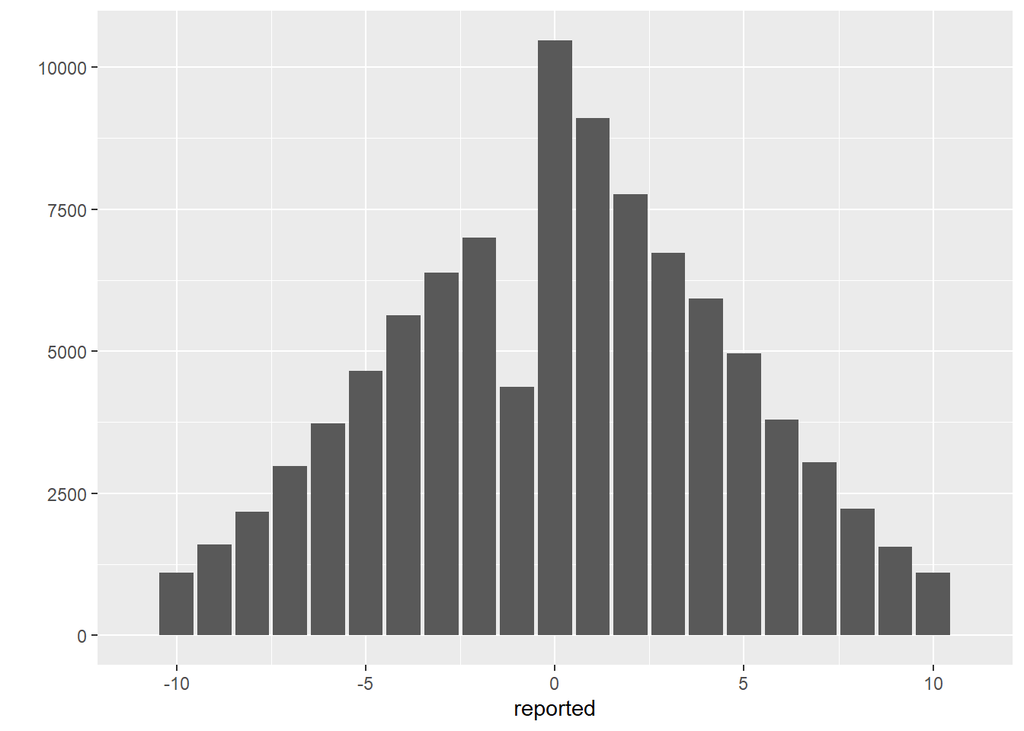

```r
qplot(df_firm_utility$R, geom = 'bar', xlim = c(-11,11), xlab = 'reported')
```

# Estimation

- Regarding the simulated data as ‘observed’ data, I recover the parameter $\theta$ by BKR method.
- See `SummaryBKR.pdf` for the step-by-step estimation procedure.

```r
# df_observed <- df_firm_utility %>%      # df_firm_utility is the 'true' data
#   select(firm, R)                       # Discard the information that cannot be observed (by researcher)
# df_observed
#
# # save data
# save(df_observed, file = '../output/data/df_observed.RData')

# load data
load(file = '../output/data/df_observed.RData')
```

## Step 1. Candidate $\theta$

- I set the initial $\theta$ to be the true $\theta$.

```r
theta_init <- theta
```

## Step 2. Simulate optimal firm behavior

- I compute the transition matrix, $P$.
- Considering the computational cost, I set the number of simulations $S$ to be $1,000$.
  - The original paper uses $S=10,000$.

```r
S <- 1000   # number of simulations

P <- compute_P(theta_init, S)
```

## Step 3. Recover the latent earnigs distribution

- I recover the latent earnings distribution by inverting $P$.
- Since some bins do not contain any firms, I have to make rows for such bins.
- Observed bins that are outside $[-20,20]$ is excluded from the data.

```r
df_pi <- compute_pi(df_observed)
```

- Then, we can invert and obtain the latent distribution.

```r
df_x <- compute_x(P, df_pi)
```

- Plot to compare $x$ and $\pi$.

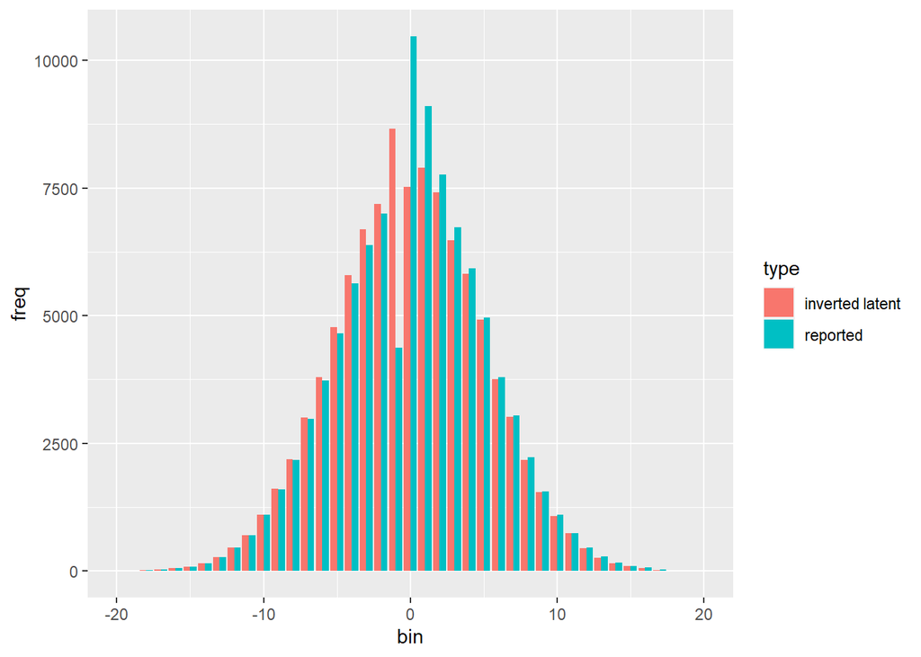

```r
df_pi_x <- full_join(df_pi, df_x, by = 'bin') %>%
  pivot_longer(-bin, names_to = 'type', values_to = 'freq')

g <- ggplot(df_pi_x, aes(x = bin, y = freq, fill = type)) +
  geom_bar(aes(fill = type), stat = 'identity', position = 'dodge', alpha =1 )+
  xlim(-20,20) +
  scale_fill_hue(name = "type", labels = c(count_e = "inverted latent", count_R ='reported'))

plot(g)
```

## Step 4 Optimizetion

- Lastly, using GMM (more precisely, SMM), I estimate the parameter.
- The objective function is
  $$L(\theta) = \left[\left(\begin{array}{l}
  \pi\\
  \boldsymbol{x}_{S}(\theta)_{(2,\ldots T)}
  \end{array}\right)-\left(\begin{array}{l}
  \boldsymbol{x}_{S}(\theta)\\
  \boldsymbol{x}_{S}(\theta)_{(1,\ldots T-1)}
  \end{array}\right)\right]^{\prime}\Omega\left[\left(\begin{array}{l}
  \pi\\
  \boldsymbol{x}_{S}(\theta)_{(2,\ldots T)}
  \end{array}\right)-\left(\begin{array}{l}
  \boldsymbol{x}_{S}(\theta)\\
  \boldsymbol{x}_{S}(\theta)_{(1,\ldots T-1)}
  \end{array}\right)\right]$$

```r
GMM_objective(theta_init, df_observed)
```

```
[1] 42109451
```

- Finally, I optimize the GMM objective function.
  - In optimization, the number of simulation, $S$, should be at least $100,000$ to get a reasonable result.
  - However, since this optimization takes a lot of time, I set $S = 10,000$.

```r
# # Nelder-Mead
# optim_result <- optim(par = c(0.5, 2, 1, 4),
#                       fn = GMM_objective,
#                       df_observed = df_observed,
#                       S = 10000,
#                       method = 'Nelder-Mead')
#
# # optim_result <- optim(par = c(0.5, 2, 1, 4),
# #                       fn = GMM_objective,
# #                       df_observed = df_observed,
# #                       method = 'L-BFGS-B',
# #                       lower = c(0.001, 1, 0, 0),
# #                       upper = c(2, 4, 2, 5),
# #                       control = list(maxit = 50))
# optim_result
```

- Let’s see the shape of objective function w.r.t. each parameter.

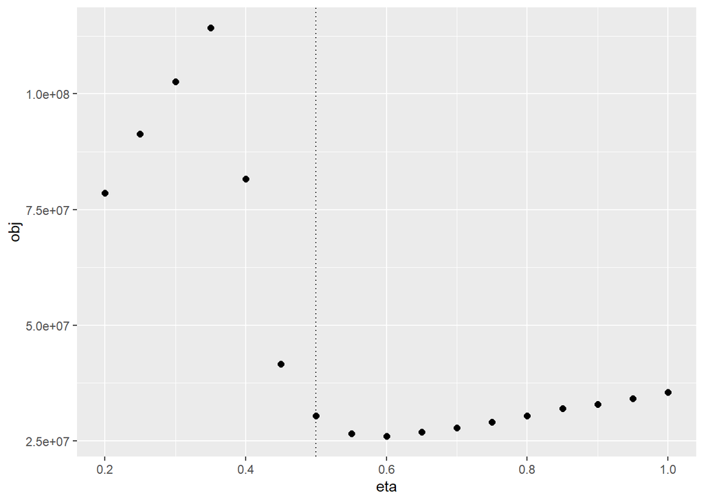

```r
S <- 50000

eta <- seq(0.2, 1, .05)
plot_objFunc(theta, 1, eta, df_observed, S = S)
```

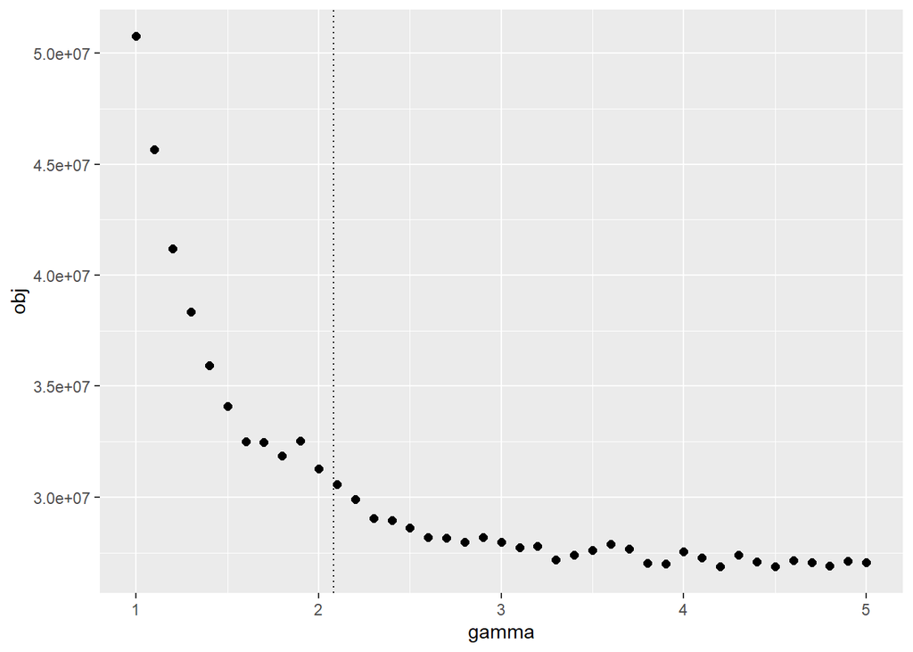

```r
gamma <- seq(1, 5, .1)
plot_objFunc(theta, 2, gamma, df_observed, S = S)
```

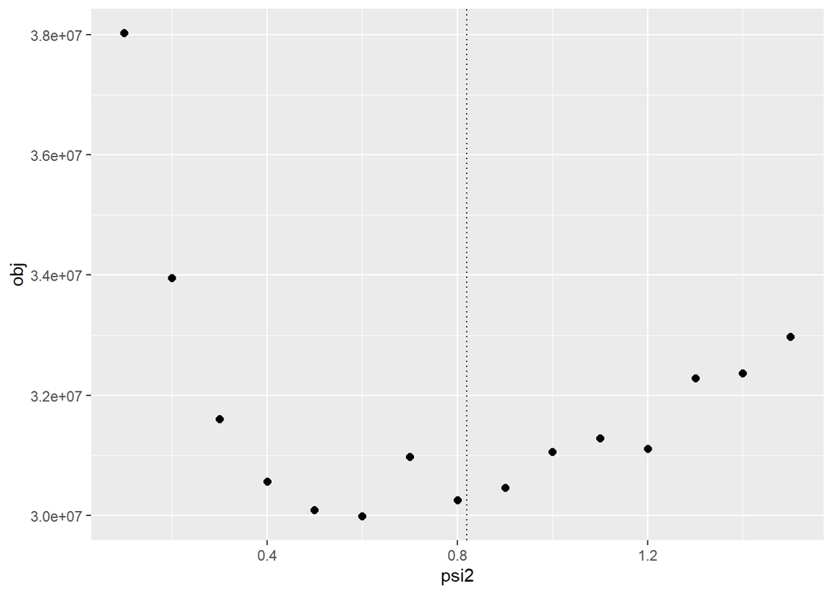

```r
psi2 <- seq(0.1, 1.5, .1)
plot_objFunc(theta, 3, psi2, df_observed, S = S)
```

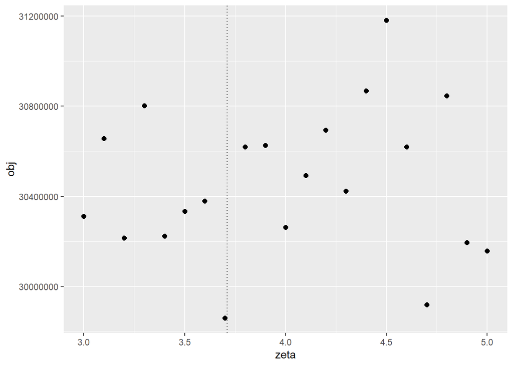

```r
zeta <- seq(3, 5, .1)
plot_objFunc(theta, 4, zeta, df_observed, S = S)
```

##### Computational burdern of BKR method

- Let’s see the time it take for each iteration given the number of simulations.
  - Notice that these times are obtained with parallelized computation (`compute_P` is parallelized.)

```r
S <- 1000
system.time(GMM_objective(theta_init, df_observed, S))
```

```
   user  system elapsed
   0.10    0.03   26.11
```

```r
S <- 10000
system.time(GMM_objective(theta_init, df_observed, S))
```

```
   user  system elapsed
   0.30    0.06  124.50
```

```r
S <- 100000
system.time(GMM_objective(theta_init, df_observed, S))
```

```
   user  system elapsed
   1.92    1.25 1051.39
```

### Original simulated obj

- The number of simulation $S$ should be at least $100,000$ to get reasonable result.
  - We need to specify the variance, which I assume to 5
- Since $\zeta$ seems not to be identified, I fiexed $\zeta = 3.71$, the true value.

```r
# simulate data
S <- 100000
df_simulated <- simulate_firm(sigma = 5, S)

# optimization
optim_result <- optimx::optimx(par = 0.3,
                               theta = c(gamma, psi2, zeta),
                               fn = CMD_obj_eta,
                               df_observed = df_observed,
                               df_simulated = df_simulated,
                               S = S,
                               method = 'BFGS')
optim_result
```

|  | p1 | value | fevals | gevals | niter | convcode | kkt1 | kkt2 | xtime |
| --- | --- | --- | --- | --- | --- | --- | --- | --- | --- |
| BFGS | 19.736 | 18.75981 | 111 | 16 | NA | 0 | FALSE | FALSE | 9399.86 |

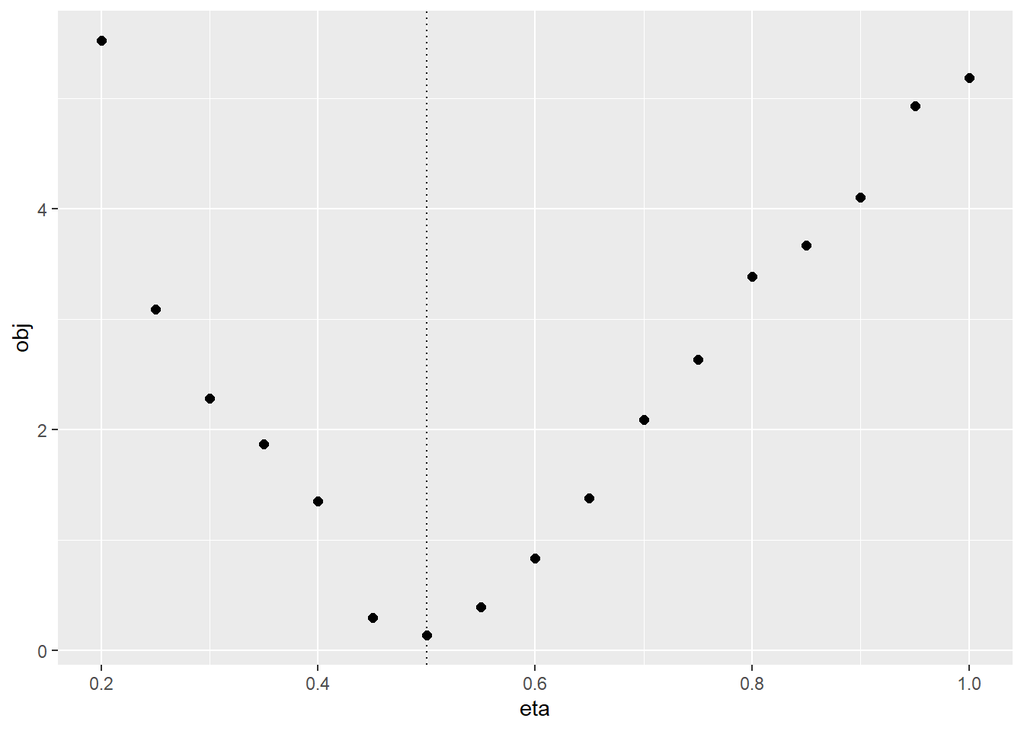

```r
graphs_CMD <- list()

eta <- seq(0.2, 1, .05)
graphs_CMD[[1]] <- plot_objFunc_CMD(theta, 1, eta,  df_observed = df_observed, df_simulated = df_simulated, S = S, parallel = TRUE)
```

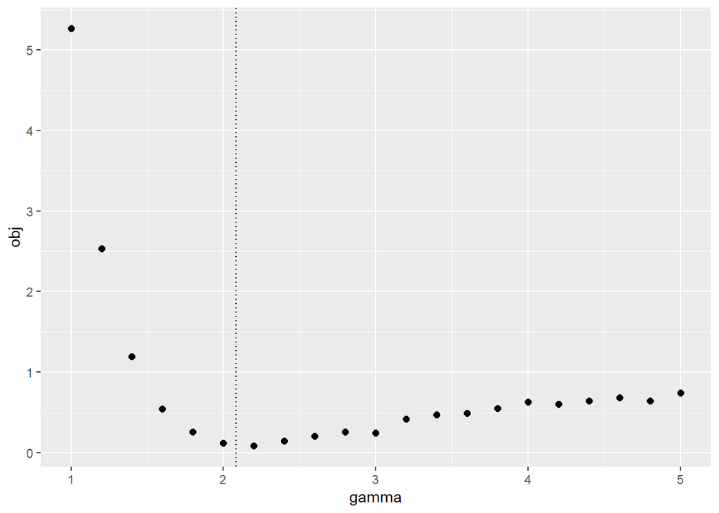

```r
gamma <- seq(1, 5, .2)
graphs_CMD[[2]] <- plot_objFunc_CMD(theta, 2, gamma, df_simulated, df_observed,  S = S, parallel = TRUE)
```

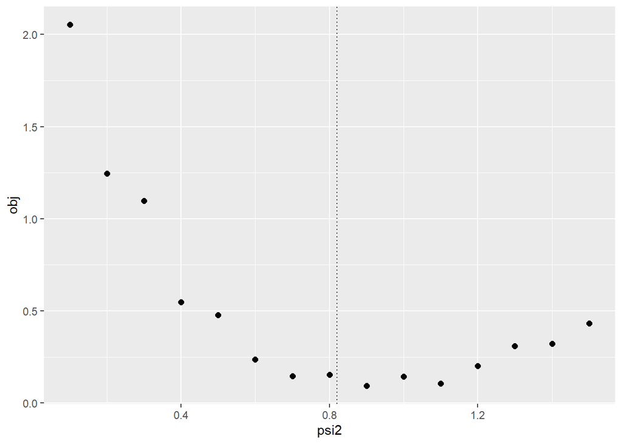

```r
psi2 <- seq(0.1, 1.5, .1)
graphs_CMD[[3]] <- plot_objFunc_CMD(theta, 3, psi2, df_simulated, df_observed,  S = S, parallel = TRUE)
```

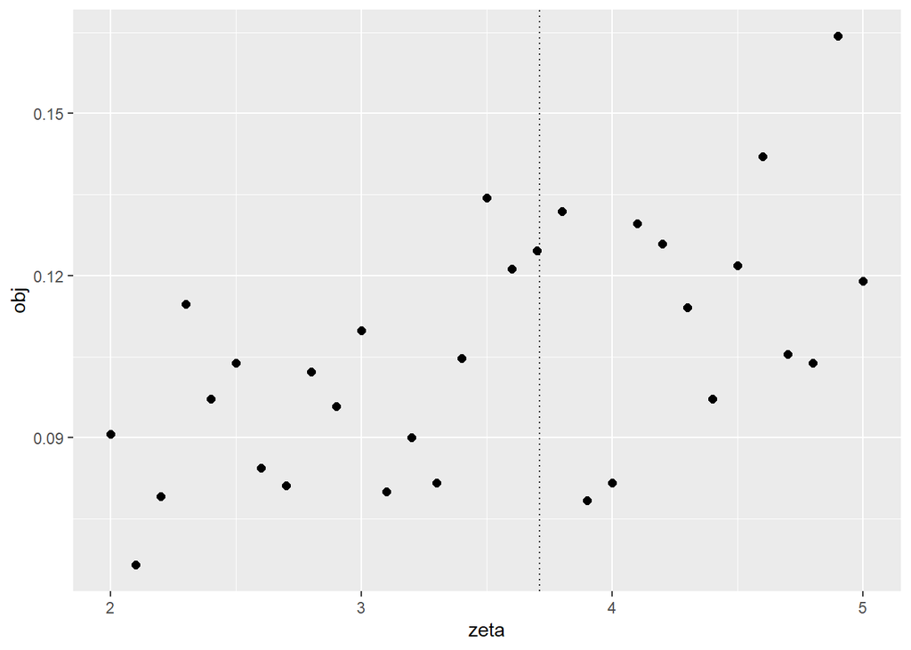

```r
zeta <- seq(2, 5, .1)
graphs_CMD[[4]] <- plot_objFunc_CMD(theta, 4, zeta, df_simulated, df_observed,  S = S, parallel = TRUE)
```

```r
for(i in 1:4){
  ggsave(plot = graphs_CMD[[i]], file = paste0( '../output/plots/CMD_objectives_', i, '.png'))
}
```

- Let’s see the time it take for each iteration given the number of simulations.
  - Notice that these computations are NOT parallelized unlike BKR method.

```r
S <- 1000
df_simulated <- simulate_firm(sigma, S)
system.time(CMD_obj(theta, df_observed, df_simulated, S))
```

```
   user  system elapsed
   0.67    0.05    0.72
```

```r
S <- 10000
df_simulated <- simulate_firm(sigma, S)
system.time(CMD_obj(theta, df_observed, df_simulated, S))
```

```
   user  system elapsed
   6.43    0.02    6.48
```

```r
S <- 100000
df_simulated <- simulate_firm(sigma, S)
system.time(CMD_obj(theta, df_observed, df_simulated, S))
```

```
   user  system elapsed
  64.41    0.06   64.67
```

#### parallel

```r
# simulate data
S <- 100
df_simulated <- simulate_firm(sigma, S)

eta <- seq(0.2, 1, .05)

# store the values of obj. func. to `obj`
obj <- numeric(length(eta))

# compute onj. func. for each parameter
library(doParallel)
cl <- makePSOCKcluster(4)
doParallel::registerDoParallel(cl)


system.time(
obj <- foreach (i = seq_along(eta),
        .packages = c('dplyr', 'purrr', 'NumbersGame'),
        .combine = 'rbind') %dopar% {
  theta_temp <- theta
  theta_temp[1] <- eta[i]
  NumbersGame::CMD_obj(theta, df_observed, df_simulated, S)
}
)
```

```
   user  system elapsed
   0.03    0.00    2.92
```

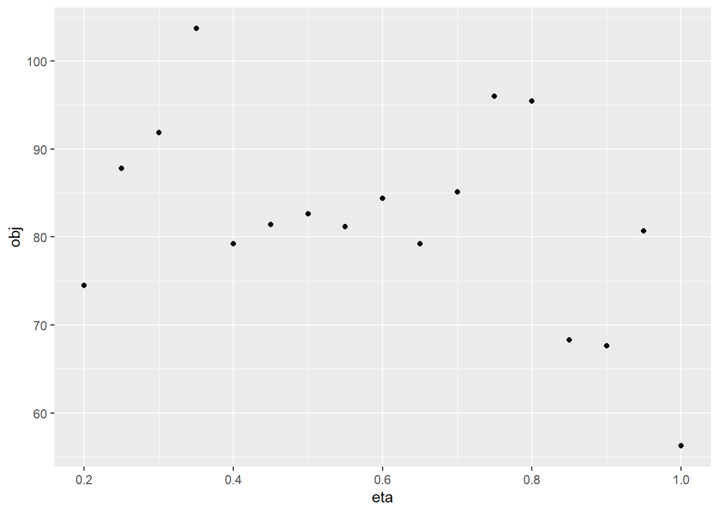

```r
qplot(eta, obj)
```

```r
stopCluster(cl)
```

## Counterfacturals

- See what happens if we increase the marginal cost parameter, $\eta$.
  - Since manipulation becomes more costly, firms that find manipulation beneficial are limited to just below the zero threshold.

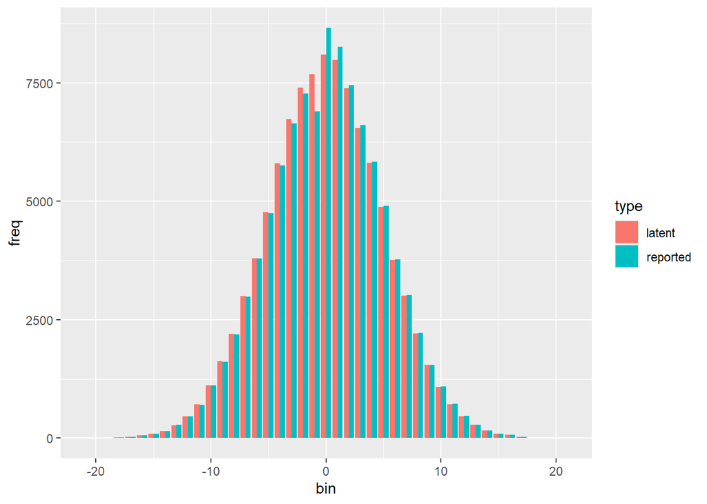

```r
theta_new <- theta
theta_new[1] <- 2

df_firm_utility_new <- compute_optimal_manipulation_simulated(df_firm, theta = theta_new, S = N)
plot_latent_reported(df_firm_utility_new)
```

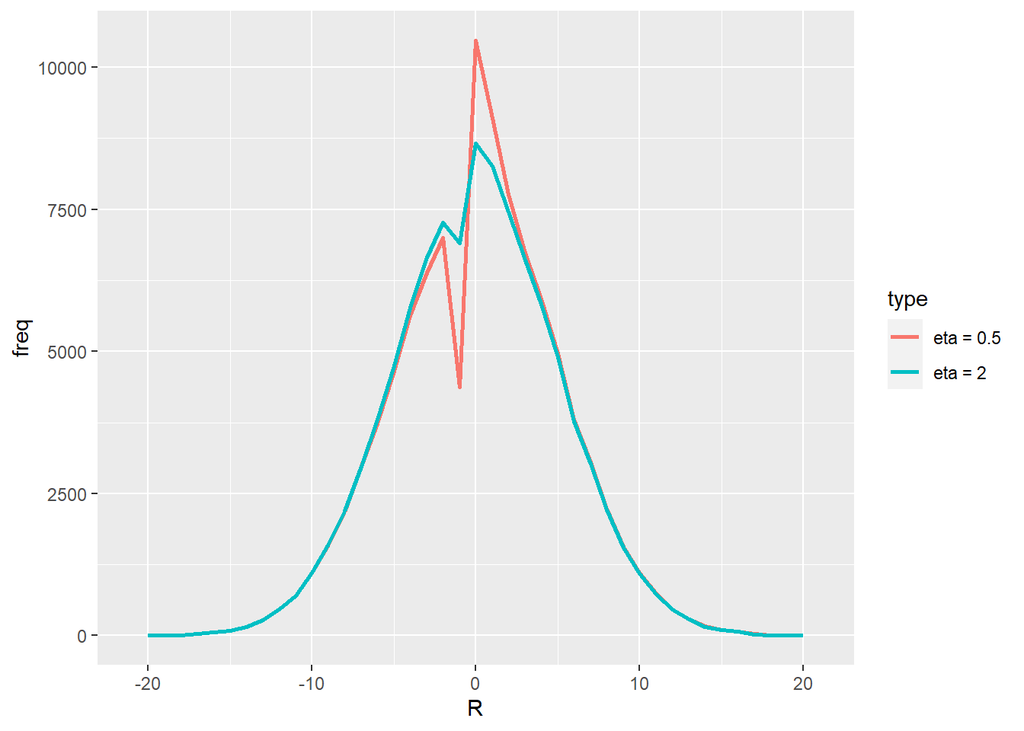

```r
df_firm_utility_aggregated <- df_firm_utility %>%
  group_by(R) %>%
  summarise('eta = 0.5' = n())

df_firm_utility_new_aggregated <- df_firm_utility_new %>%
  group_by(R) %>%
  summarise('eta = 2' = n())

df_compare = left_join(df_firm_utility_aggregated, df_firm_utility_new_aggregated) %>% pivot_longer(-R, names_to = 'type', values_to = 'freq')

ggplot(df_compare, aes(x = R, y = freq, fill = type)) +
    geom_line(aes(color = type), size = 1)+
    xlim(-21,21)
```